# Event network analysis

Kang

分析对象是两个事件：“大米”（rice），“酷暑”（hot）。计算了两个事件中所有用户的度量中心度（Degree centrality）、中介中心度（Betweenness centrality）。其中，大米事件的前10位度量中心度高值用户如下。

```r
graph_cen[[1]] %>%
  arrange(-cen_degree) %>%
  select(retweeted_userid = name, retweeted_username = author_username, cen_degree) %>%
  head(10) %>%
  knitr::kable()
```

| retweeted_userid | retweeted_username | cen_degree |
| --- | --- | --- |
| 87656713 | NA | 3758 |
| 822750195645485057 | amasehimika147 | 2464 |
| 121500765 | DrTomabechi | 1648 |
| 776651743077675008 | rainbow_309_204 | 643 |
| 1473097608206106626 | NA | 598 |
| 1514223953639718913 | mewmew_344 | 545 |
| 772049555164499968 | Beyond_Climate | 514 |
| 4620919093 | NA | 471 |
| 33464495 | NA | 392 |
| 1526335053898231808 | NA | 381 |

大米事件中介中心度前10位如下。

```r
graph_cen[[1]] %>%
  arrange(-cen_between) %>%
  select(retweeted_userid = name, retweeted_username = author_username, cen_between) %>%
  head(10) %>%
  knitr::kable()
```

| retweeted_userid | retweeted_username | cen_between |
| --- | --- | --- |
| 822750195645485057 | amasehimika147 | 10237.923 |
| 955818757892448256 | nnyrG6mn5UqyPy1 | 6251.327 |
| 1031205553911939073 | a57454412 | 3961.657 |
| 708305398793547776 | lililily_moon | 3283.414 |
| 3945279974 | sally38622573 | 2078.445 |
| 1514223953639718913 | mewmew_344 | 1885.074 |
| 776651743077675008 | rainbow_309_204 | 1868.262 |
| 1358220296625418240 | o1ZBoSwhXrk51dP | 1279.521 |
| 4712075358 | ohanachan28 | 1120.665 |
| 157300022 | takayan309 | 1048.872 |

酷暑事件度量中心度前10位如下。

```r
graph_cen[[2]] %>%
  arrange(-cen_degree) %>%
  select(retweeted_userid = name, retweeted_username = author_username, cen_degree) %>%
  head(10) %>%
  knitr::kable()
```

| retweeted_userid | retweeted_username | cen_degree |
| --- | --- | --- |
| 1161797133424455680 | NA | 10568 |
| 188620283 | ozawa_jimusho | 6722 |
| 249603227 | NA | 5618 |
| 94513095 | hiranok | 4327 |
| 1161186227279654912 | NA | 3667 |
| 1183178208398602240 | nipponkairagi | 3562 |
| 234201183 | NA | 3239 |
| 543860205 | HuffPostJapan | 3041 |
| 143328179 | hoku_mai | 2886 |
| 64695621 | Kitsch_Matsuo | 2869 |

酷暑事件中介中心度前10位如下。

```r
graph_cen[[2]] %>%
  arrange(-cen_between) %>%
  select(retweeted_userid = name, retweeted_username = author_username, cen_between) %>%
  head(10) %>%
  knitr::kable()
```

| retweeted_userid | retweeted_username | cen_between |
| --- | --- | --- |
| 2250342156 | yadanetnagano | 7634348 |
| 167832583 | kouzai2007 | 5949702 |
| 1239539301181870080 | ripplemark733 | 5931358 |
| 746436258 | OkadaAim990 | 5776206 |
| 2912822551 | jcpshonan1922 | 5752668 |
| 7323692 | CSambo | 4968662 |
| 64695621 | Kitsch_Matsuo | 4955695 |
| 69008611 | oricquen | 3851891 |
| 1515786181 | IkedaKiyohiko | 3605948 |
| 1268413900745175040 | qoib08EbfZXR4cY | 3587894 |

两个事件的网络图如下，community以颜色区分，并且展示中心用户在网络中的位置，标签为账户名（就是艾特后面那串）。对于数据库中无对应账户名的，以空标签框表示。

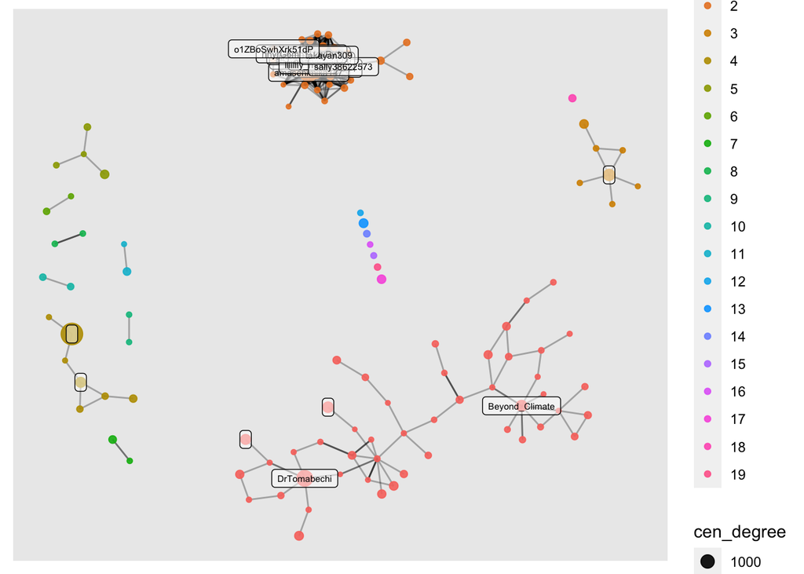

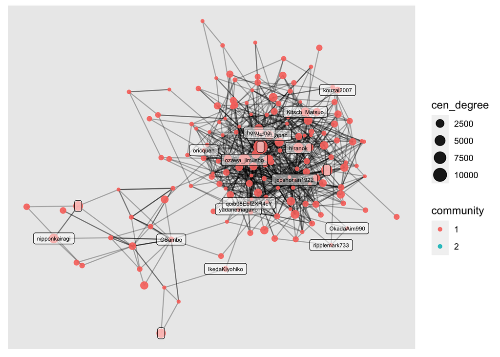

```r
net_plot_comm
```

**为了方便识别这些中心节点都是些什么用户，随报告附上**各个中心节点对应的源头用户相关资料，包括用户的ID、账户名、账户描述、发过的被广为传播的推文内容。

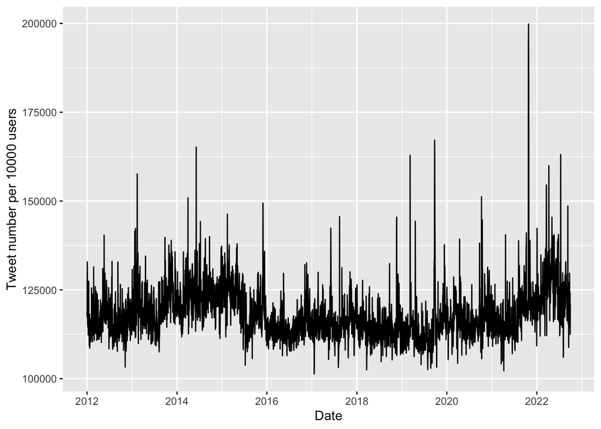

```r
tar_load(general_plot_dt)
ggplot(general_plot_dt) +
  geom_line(aes(date, tw_int)) +
  labs(x = "Date", y = "Tweet number per 10000 users")
```

此外，附上你之前学会有用过的、类似的总推文数和每日活跃用户数的变化图如下。

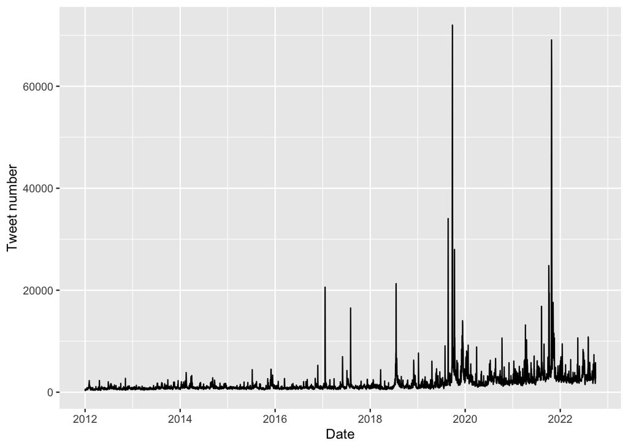

```r
ggplot(general_plot_dt) +
  geom_line(aes(date, tw_num)) +
  labs(x = "Date", y = "Tweet number")
```

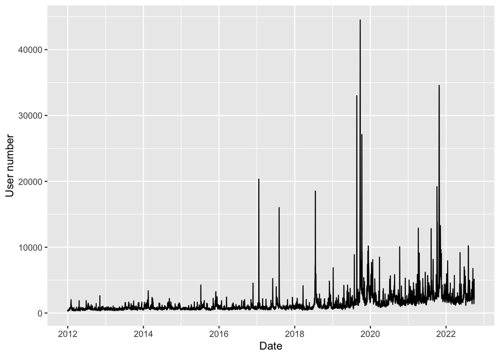

```r
ggplot(general_plot_dt) +
  geom_line(aes(date, usr_num)) +
  labs(x = "Date", y = "User number")
```

由于数据差异很大，考虑用对数尺度。

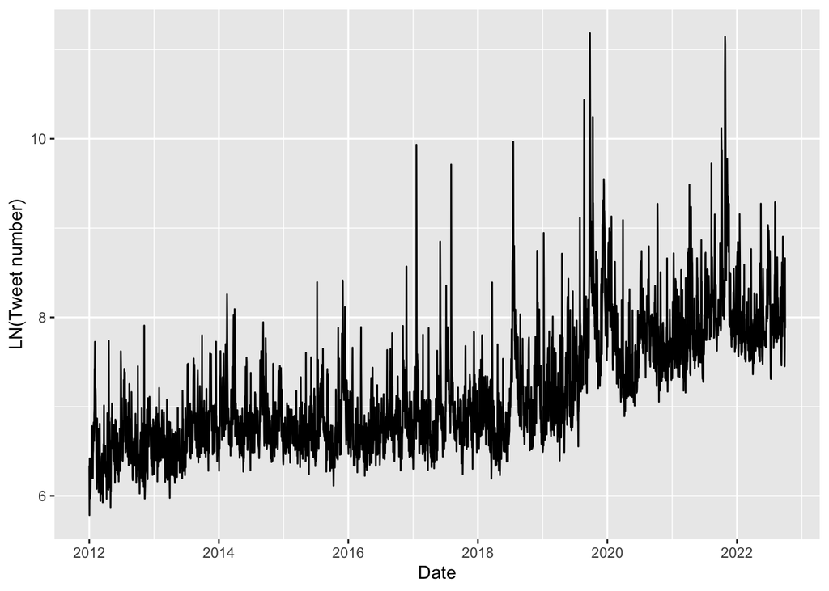

```r
ggplot(general_plot_dt) +
  geom_line(aes(date, log(tw_num))) +
  labs(x = "Date", y = "LN(Tweet number)")
```

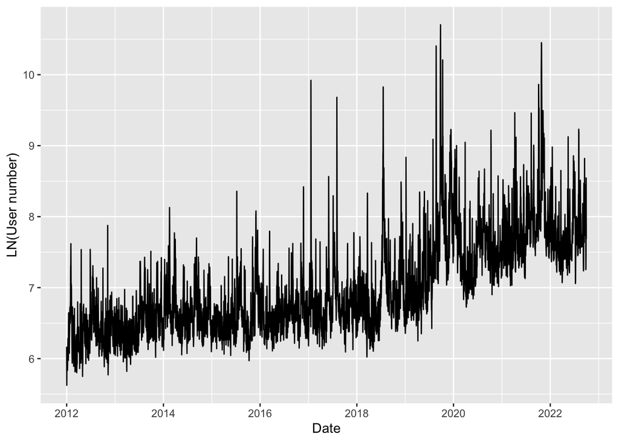

```r
ggplot(general_plot_dt) +
  geom_line(aes(date, log(usr_num))) +
  labs(x = "Date", y = "LN(User number)")
```